# Prediction Assignment Write up for Practical Machine Learning

Steven’s write up for the Johns Hopkins Coursera Data Science specialization

January 23, 2016

# Summary

The analysis uses two different learners, one fast ( **Random Forrest**), and one slow (**Extream Gradient Boosting** ) with the intent to combine predictors if they both do not perform optimally.

# Getting and Cleaning the Data

The training data for this project are available here: https://d396qusza40orc.cloudfront.net/predmachlearn/pml-training.csv

The test data are available here: https://d396qusza40orc.cloudfront.net/predmachlearn/pml-testing.csv

It is important to examine the data fully for missing values. It became apparent that there was a second code used for missing values (*#DIV/0!*). Now, that we know all of the codes used for missing values, the data is read into a data frame:

```r
#download.file("https://d396qusza40orc.cloudfront.net/predmachlearn/pml-training.csv","training.csv")
#download.file("https://d396qusza40orc.cloudfront.net/predmachlearn/pml-testing.csv","testing.csv")
training <- read.csv("training.csv", na.strings = c("NA", "#DIV/0!"));testing <- read.csv("testing.csv", na.strings = c("NA", "#DIV/0!"))
```

Using the paper by Velloso, E., et. al. as a reference, there are only a handful of variables that are useful for the prediction. The variables of interest have **belt**, **arm**, **dumbbell**, and **forearm** in their names. Therefore, reducing the variables for us.

```r
dim(training)
```

```
## [1] 19622   160
```

```r
sensorColumns = grep(pattern = "_belt|_arm|_dumbbell|_forearm", names(training))
training = training[, c(sensorColumns,160)]
dim(training)
```

```
## [1] 19622   153
```

After the four types of variables are selected, the next course of action is to deal with the missing values in the data frame. Unfortunately, the vast amount of missing values does not allow us to impute the data. Consequently, columns with missing values were removed as part of the data cleaning process. Next, variable selection was applied to the testing set to avoid errors.

```r
missingData = is.na(training)
omitColumns = which(colSums(missingData) > 19000)
training = training[, -omitColumns]
dim(training)
```

```
## [1] 19622    53
```

```r
testing <- testing[colnames(testing) %in% colnames(training)]
```

# Exploring the Data

With a high dimension data set, t-Distributed Stochastic Neighbor Embedding (**t-SNE**) was chosen to see and identify any patterns in the data. High dimensional visualization methods provide insight as to which machine learning techniques to utilize.

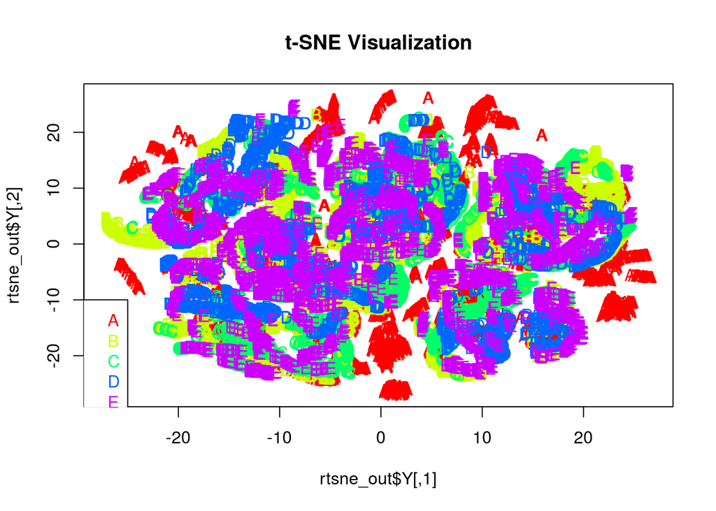

```r
suppressMessages(library(Rtsne))
set.seed(323)
rtsne_out <- Rtsne(data.matrix(training), max_iter=500)
colors = rainbow(length(unique(training$classe)))
names(colors) = unique(training$classe)
plot(rtsne_out$Y, t='n', main="t-SNE Visualization")
text(rtsne_out$Y, labels=training$classe, col=colors[training$classe])
legend(-30,-10,unique(training$classe),text.col=colors )
```

This visualization technique preserves the high dimension structure and projects that structure into two or three-dimensional space. The figure does not distinguish nice clusters, therefore, a cluster approach will not be applied to this data set.In addition, a decision tree would yield poor results on this data set. More on **t-SNE** can be found in this paper http://www.jmlr.org/papers/volume9/vandermaaten08a/vandermaaten08a.pdf.